# Szeregi czasowe - Projekt zaliczeniowy

### Dekompozycja za pomocą ruchomej średniej

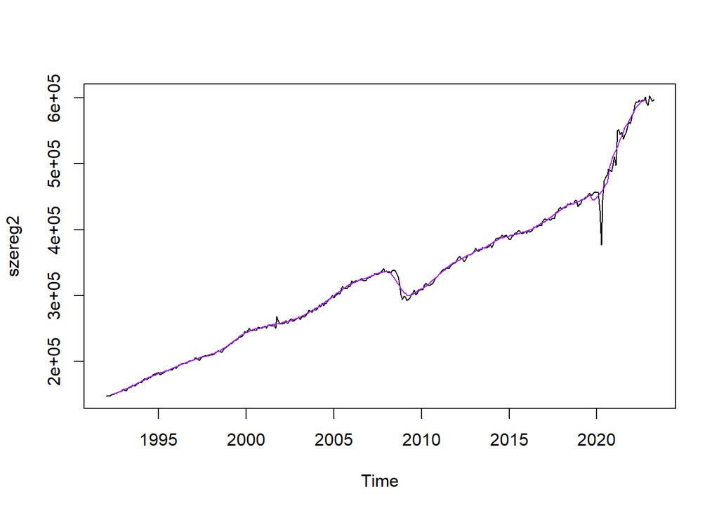

```r
ruchomesrednie2 <- filter(szereg2, sides = 2, filter = rep(1/12,12))
plot(szereg2)
lines(ruchomesrednie2, col = "purple")
```

### Dekompozycja na podstawie modelu regresji

#### Trend liniowy

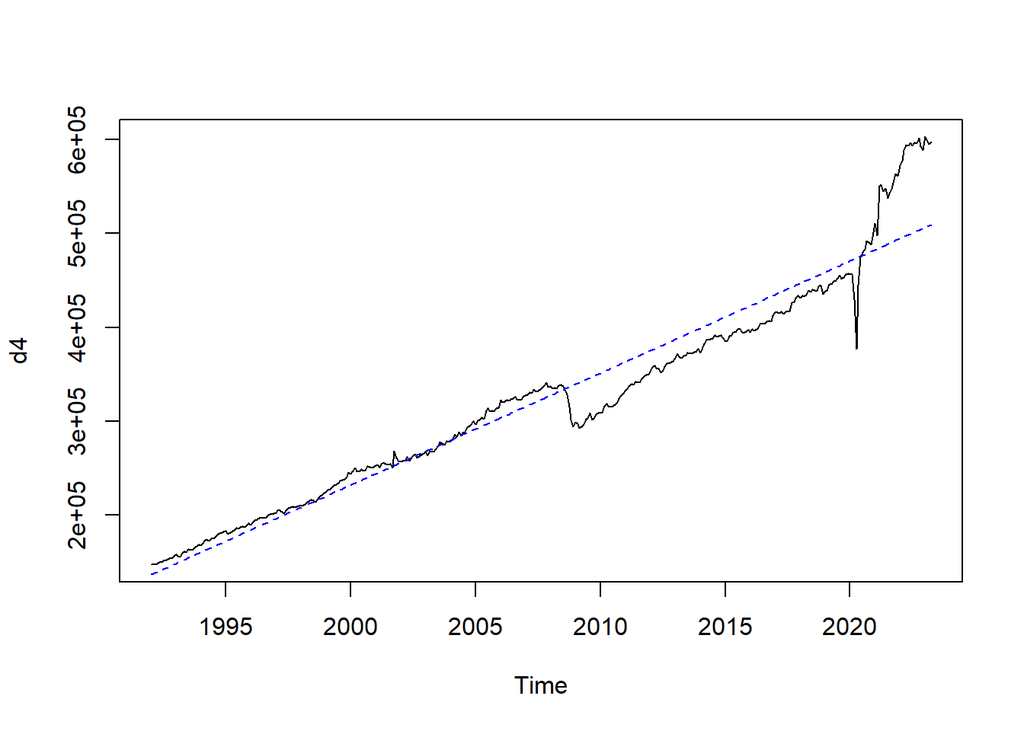

```r
d4 <- szereg2
elec_model <- tslm(d4 ~ trend)
plot(d4)
lines(fitted(elec_model), col = "blue", lty = 2)
```

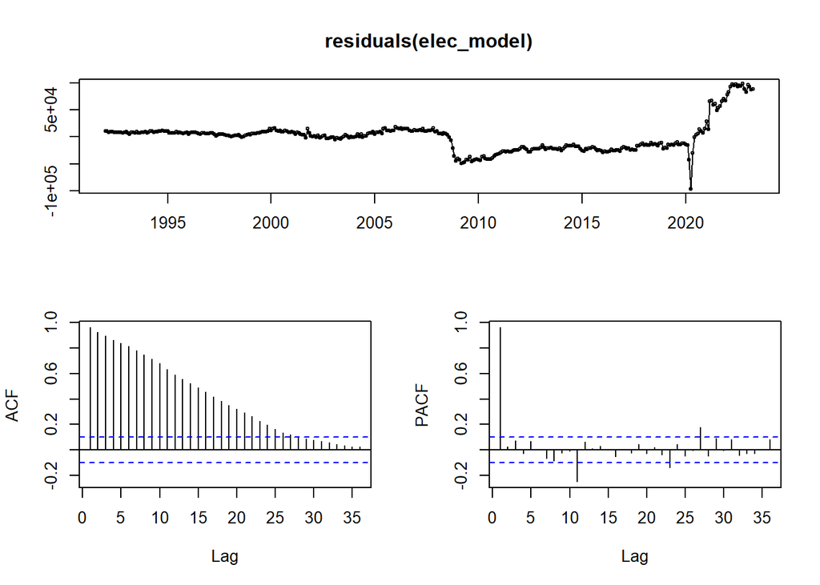

```r
tsdisplay(residuals(elec_model))
```

#### Trend liniowy i sezonowość

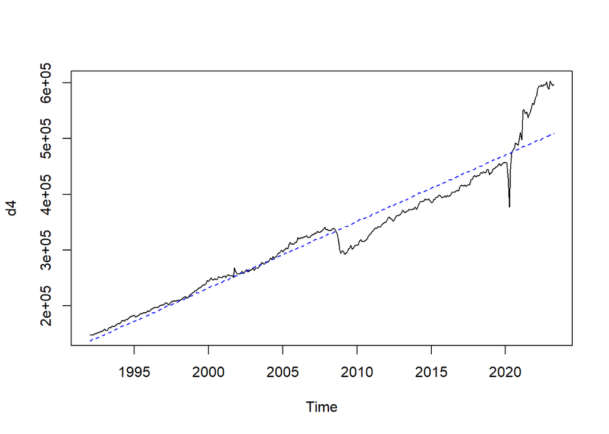

```r
elec_model_sezon <- tslm(d4 ~ trend +season)
plot(d4)
lines(fitted(elec_model_sezon), col="blue", lty=2)
```

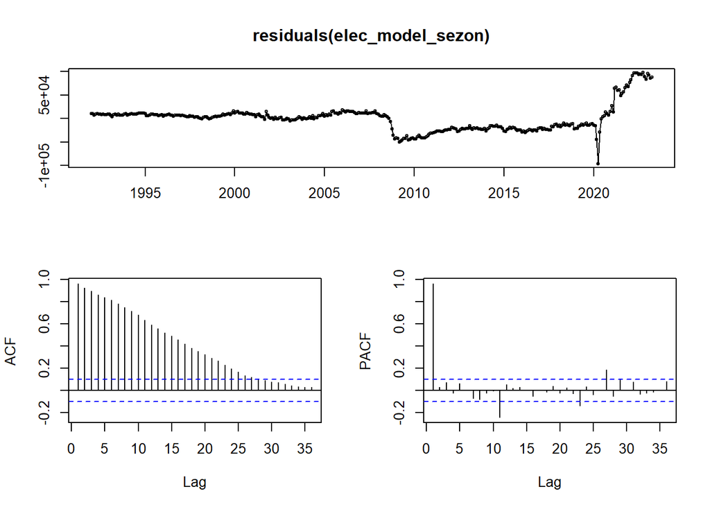

```r
tsdisplay(residuals(elec_model_sezon))
```

#### Trend liniowy, sezonowość i Box-Cox

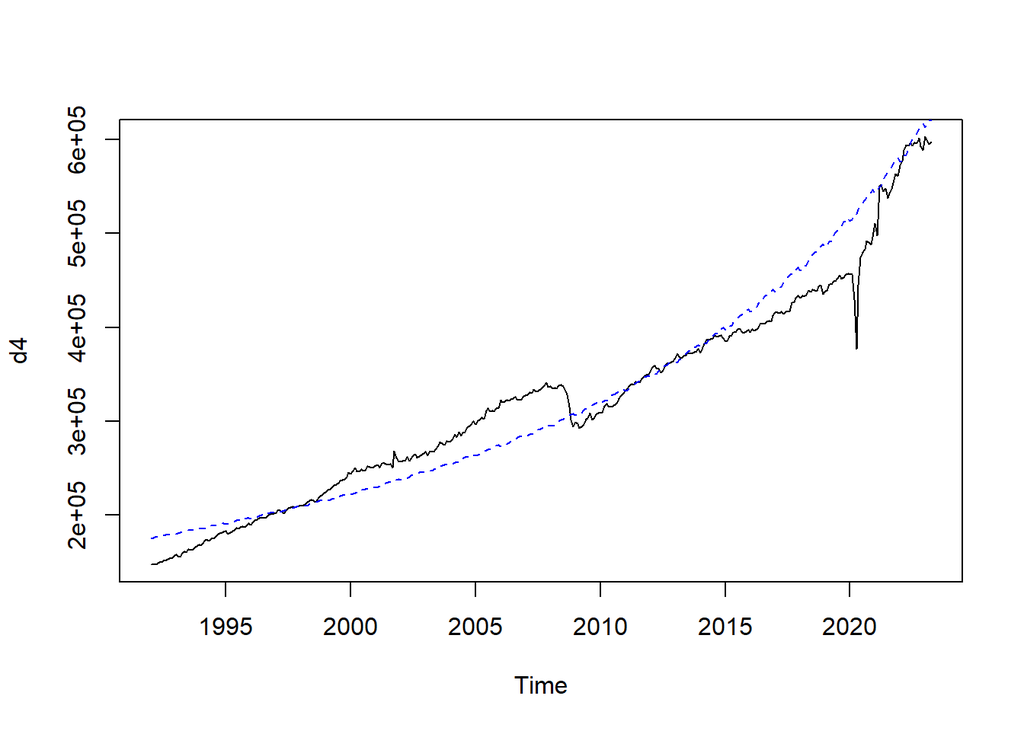

```r
elec_model_boxcox <- tslm(d4 ~ trend + season, lambda="auto")
plot(d4)
lines(fitted(elec_model_boxcox), col="blue", lty=2)
```

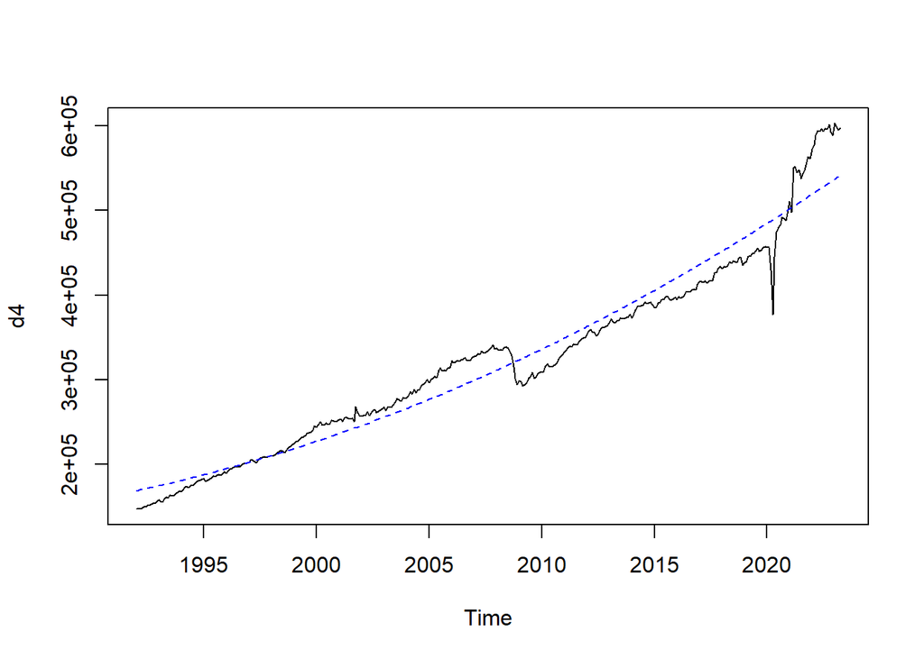

```r
bc <- tslm(d4 ~ poly(trend, raw=TRUE, degree = 2))
plot(d4)
lines(fitted(bc), col = "blue", lty = 2)
```

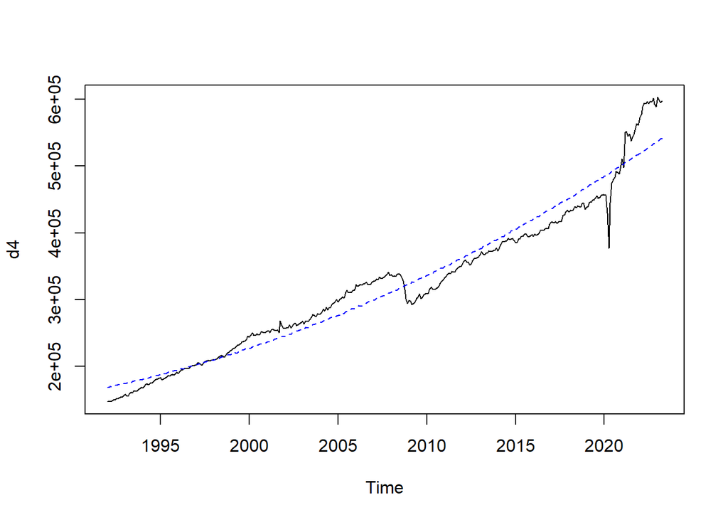

```r
bc_season <- tslm(d4 ~ poly(trend, raw=TRUE, degree = 2)+ season)
plot(d4)
lines(fitted(bc_season), col = "blue", lty = 2)
```

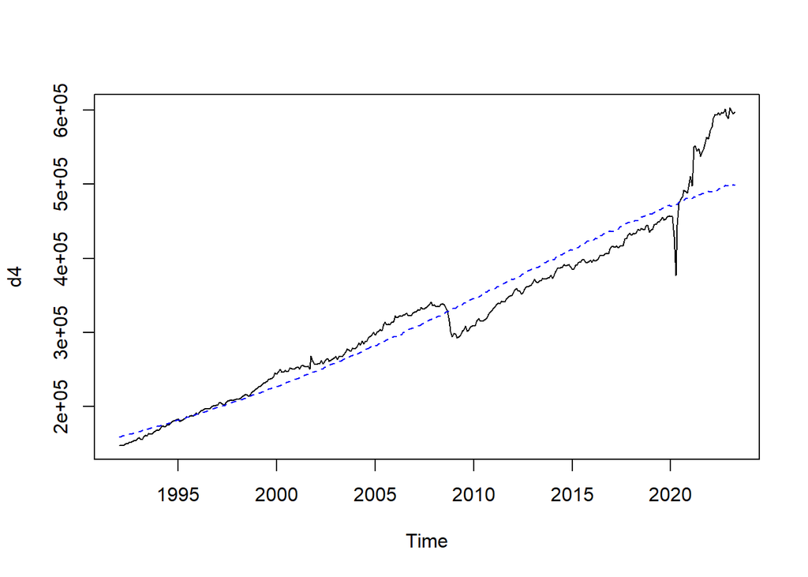

```r
bc_season_boxcox <- tslm(d4 ~ poly(trend, raw=TRUE, degree = 2)+ season, lambda="auto")
plot(d4)
lines(fitted(bc_season_boxcox), col = "blue", lty = 2)
```

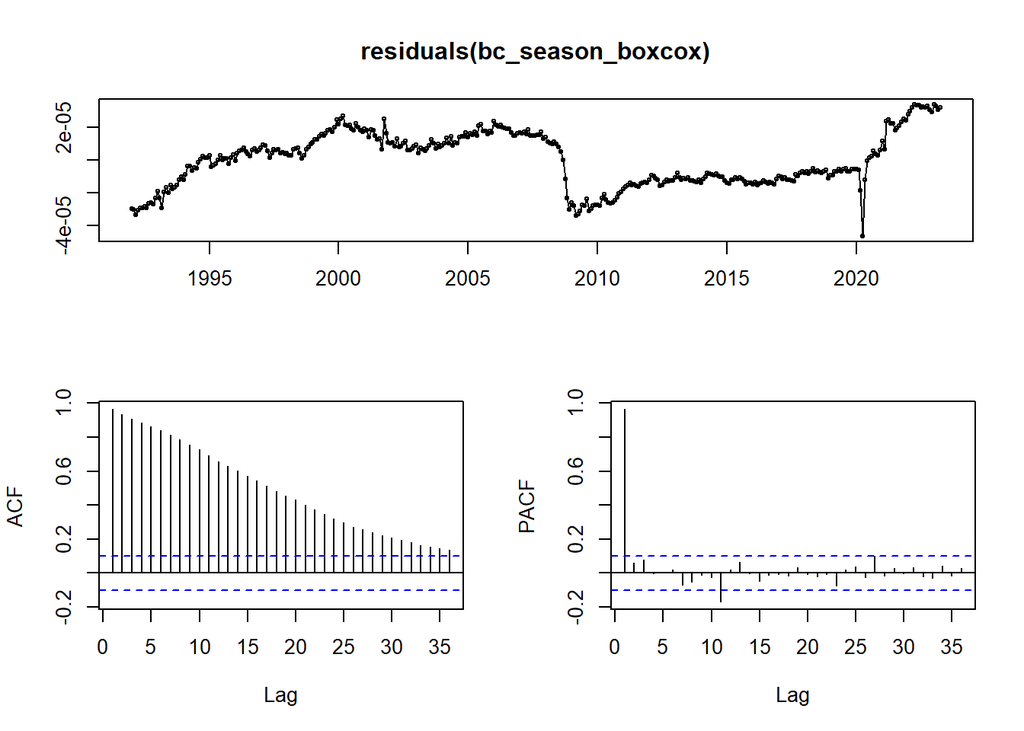

```r
tsdisplay(residuals(bc_season_boxcox))
```

#### Dla wielomianu st 5

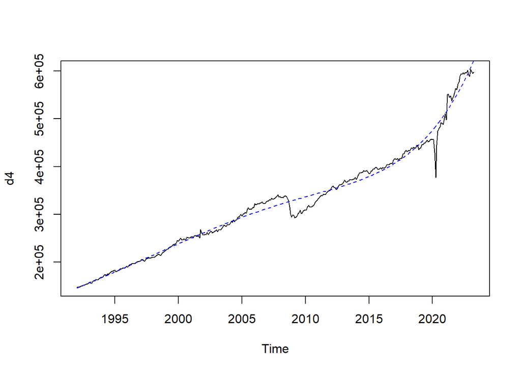

```r
bc <- tslm(d4 ~ poly(trend, raw=TRUE, degree = 5))
plot(d4)
lines(fitted(bc), col = "blue", lty = 2)
```

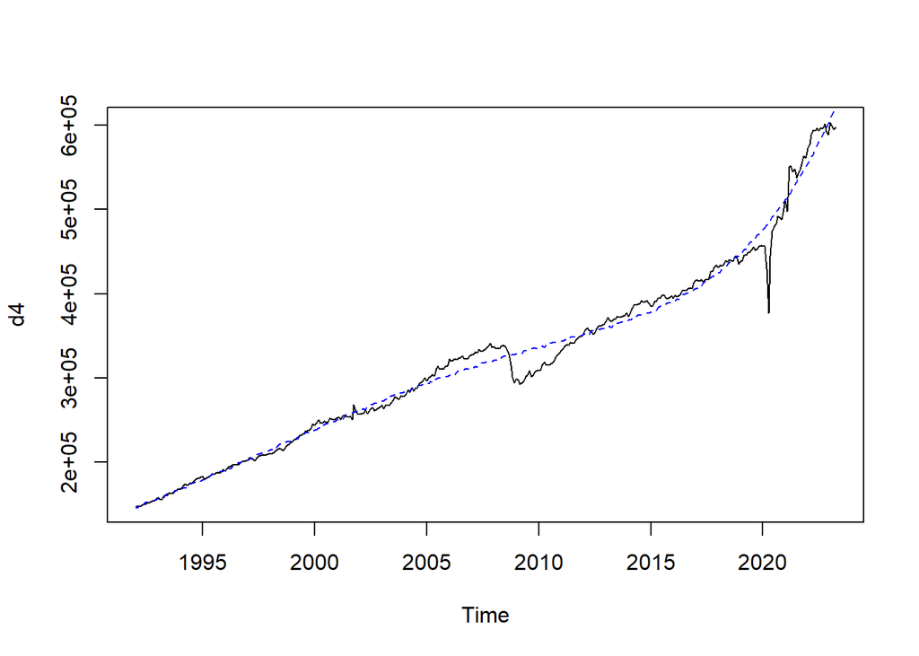

```r
bc_season <- tslm(d4 ~ poly(trend, raw=TRUE, degree = 5)+ season)
plot(d4)
lines(fitted(bc_season), col = "blue", lty = 2)
```

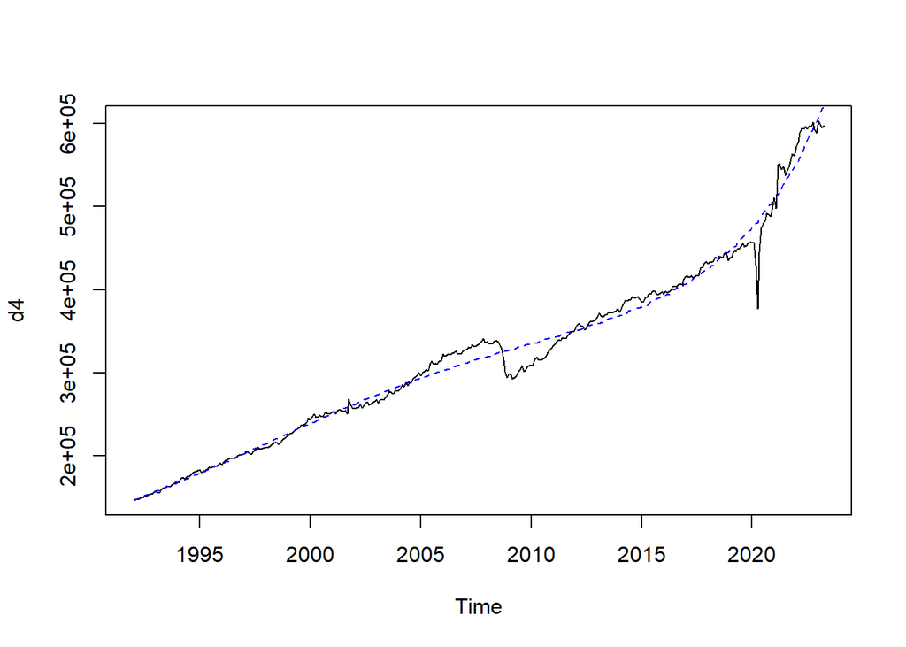

```r
bc_season_boxcox <- tslm(d4 ~ poly(trend, raw=TRUE, degree = 5)+ season, lambda="auto")
plot(d4)
lines(fitted(bc_season_boxcox), col = "blue", lty = 2)
```

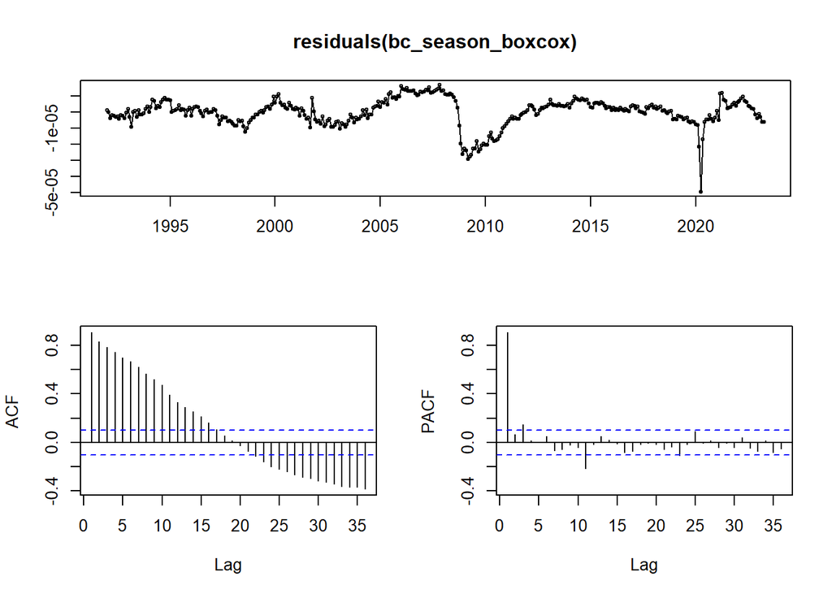

```r
tsdisplay(residuals(bc_season_boxcox))
```

# **Uczynienie szeregu stacjonarnym**

## Szereg z wyraźną sezonowością

### Eliminacja trendu i sezonowości

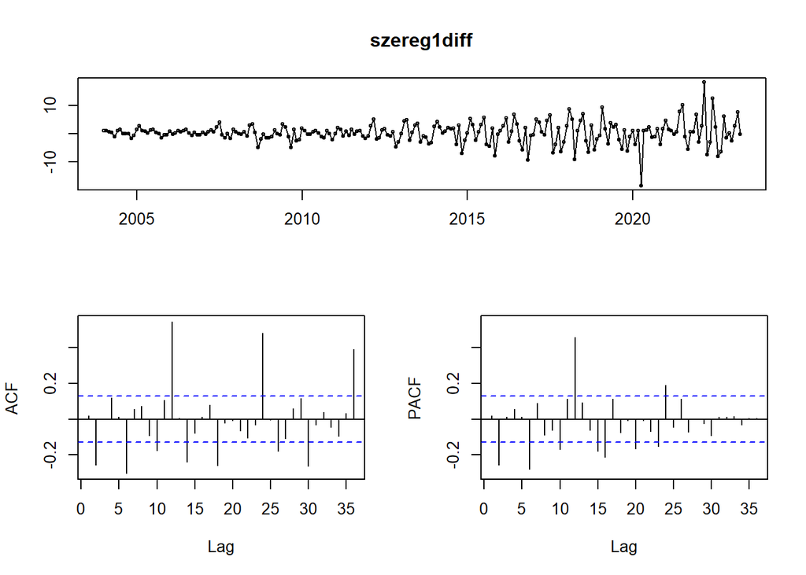

```r
# Eliminacja trendu, sezonowości szereg1
#usuwamy trend
szereg1diff <- diff(szereg1)
tsdisplay(szereg1diff)
```

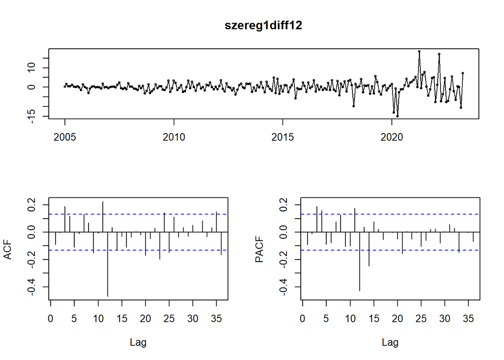

```r
#trendu nie ma, jest sezonowosc
# usuwamy sezonowosc
szereg1diff12 <- diff(szereg1diff, lag=12)
tsdisplay(szereg1diff12)
```

Warto sprawdzić: MA(3), MA(11), MA(12), MA(23), MA(36), AR(3), AR(12), AR(14)

Szereg nie jest realizacja szumu białego ponieważ wartosci korelacj sa i wystają poza przedział ufności

## Szereg z wyraźnym trendem

### Eliminacja trendu

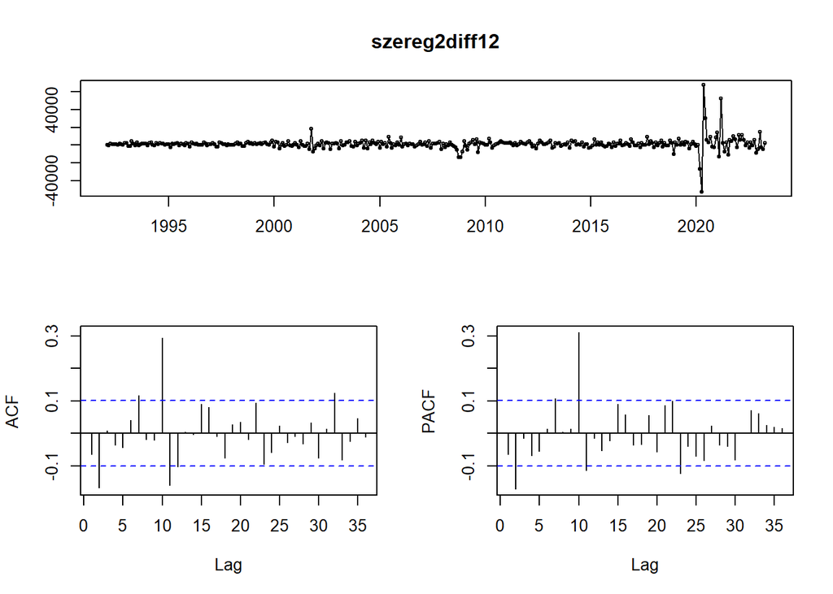

```r
# Eliminacja trendu, sezonowości szereg2
#usuwamy trend
szereg2diff <- diff(szereg2)
szereg2diff12 <- szereg2diff
tsdisplay(szereg2diff12)
```

```r
#trendu nie ma i nie ma sezonowosci
```

Warto sprawdzić: MA(2), MA(11), MA(12), AR(10), AR(23)

Szereg nie jest realizacja szumu białego ponieważ wartosci korelacj są duże i wystają poza przedział ufności

# **Wyznaczenie współczynników modelu AR**

## Szereg z wyraźną sezonowością

Dla wszystkich metod rząd modelu jest zgodny. Automatyczny dobór jest bardziej zbliżony do metody Yule-Walkera.

### Metoda Yule-Walkera

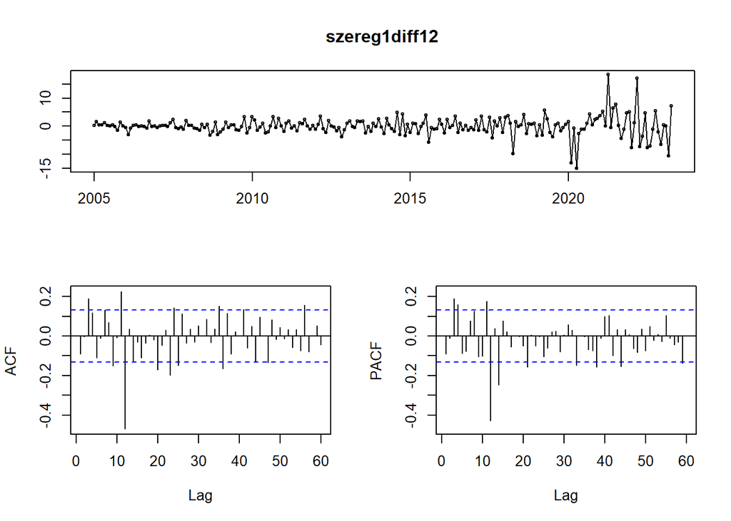

```r
#MA(23)
#AR(14)
tsdisplay(szereg1diff12, lag.max = 60)
```

```r
szereg1diff12yw <- ar(szereg1diff12, aic=FALSE, order.max = 14, method=c("yule-walker"))
szereg1diff12yw
```

```
##
## Call:
## ar(x = szereg1diff12, aic = FALSE, order.max = 14, method = c("yule-walker"))
##
## Coefficients:
##       1        2        3        4        5        6        7        8
##  0.0042  -0.0536   0.1822   0.1016  -0.0907   0.0008   0.0644   0.1106
##       9       10       11       12       13       14
## -0.0641  -0.0189   0.1683  -0.4149   0.0370  -0.2477
##
## Order selected 14  sigma^2 estimated as  8.027
```

### Metoda największej wiarygodności (MLE)

```r
szereg1diff12mle <- ar(szereg1diff12, aic=FALSE, order.max = 14, method=c("mle"))
szereg1diff12mle
```

```
##
## Call:
## ar(x = szereg1diff12, aic = FALSE, order.max = 14, method = c("mle"))
##
## Coefficients:
##       1        2        3        4        5        6        7        8
##  0.0373  -0.0761   0.1922   0.1003  -0.0817  -0.0036   0.0471   0.0984
##       9       10       11       12       13       14
## -0.0655   0.0080   0.1898  -0.4669   0.0590  -0.2541
##
## Order selected 14  sigma^2 estimated as  6.963
```

### Dobór automatyczny

```r
szereg1diff12auto <- ar(szereg1diff12, aic=TRUE)
szereg1diff12auto
```

```
##
## Call:
## ar(x = szereg1diff12, aic = TRUE)
##
## Coefficients:
##       1        2        3        4        5        6        7        8
##  0.0042  -0.0536   0.1822   0.1016  -0.0907   0.0008   0.0644   0.1106
##       9       10       11       12       13       14
## -0.0641  -0.0189   0.1683  -0.4149   0.0370  -0.2477
##
## Order selected 14  sigma^2 estimated as  8.027
```

## Szereg z wyraźnym trendem

Funkcja automatyczna dobrała model rzędu 11

### Metoda Yule-Walkera

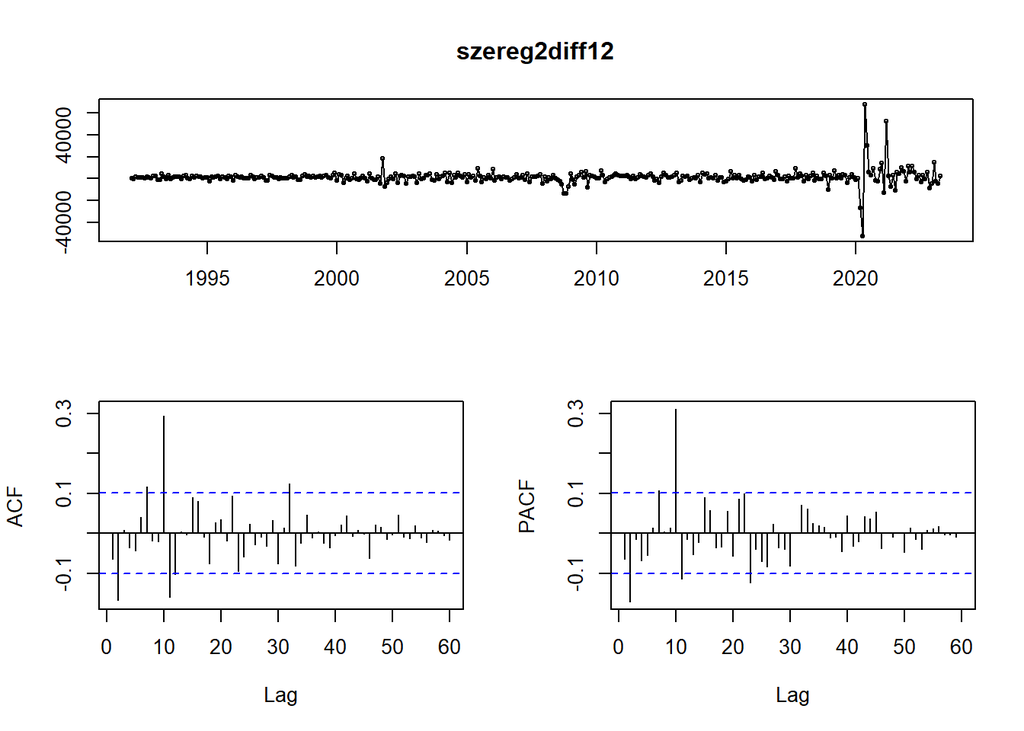

```r
#MA(11)
#AR(23)
tsdisplay(szereg2diff12, lag.max = 60)
```

```r
szereg2diff12yw <- ar(szereg2diff12, aic=FALSE, order.max = 23, method=c("yule-walker"))
szereg2diff12yw
```

```
##
## Call:
## ar(x = szereg2diff12, aic = FALSE, order.max = 23, method = c("yule-walker"))
##
## Coefficients:
##       1        2        3        4        5        6        7        8
## -0.0440  -0.1565  -0.0415  -0.0283  -0.0347   0.0129   0.1101   0.0702
##       9       10       11       12       13       14       15       16
## -0.0158   0.3207  -0.1358  -0.0650   0.0030  -0.0230   0.0803   0.0611
##      17       18       19       20       21       22       23
## -0.0218  -0.0363   0.0652  -0.0393   0.0696   0.0918  -0.1230
##
## Order selected 23  sigma^2 estimated as  36770699
```

### Metoda największej wiarygodności (MLE)

```r
szereg2diff12mle <- ar(szereg2diff12, aic=FALSE, order.max = 23, method=c("mle"))
szereg2diff12mle
```

```
##
## Call:
## ar(x = szereg2diff12, aic = FALSE, order.max = 23, method = c("mle"))
##
## Coefficients:
##       1        2        3        4        5        6        7        8
## -0.0391  -0.1516  -0.0453  -0.0256  -0.0334   0.0093   0.1105   0.0661
##       9       10       11       12       13       14       15       16
## -0.0238   0.3269  -0.1409  -0.0701   0.0125  -0.0237   0.0817   0.0620
##      17       18       19       20       21       22       23
## -0.0181  -0.0370   0.0714  -0.0455   0.0704   0.0960  -0.1341
##
## Order selected 23  sigma^2 estimated as  34008011
```

### Dobór automatyczny

```r
szereg2diff12auto <- ar(szereg2diff12, aic=TRUE)
szereg2diff12auto
```

```
##
## Call:
## ar(x = szereg2diff12, aic = TRUE)
##
## Coefficients:
##       1        2        3        4        5        6        7        8
## -0.0516  -0.1775  -0.0497  -0.0601  -0.0180   0.0417   0.1077   0.0551
##       9       10       11
##  0.0175   0.2998  -0.1150
##
## Order selected 11  sigma^2 estimated as  37601749
```

# **Wyznaczenie współczynników dla modelu MA(q)**

## Szereg z wyraźną sezonowością

```r
#szereg1
szereg1arima <- Arima(szereg1diff12 , order = c(0,0,23))
summary(szereg1arima)
```

```
## Series: szereg1diff12
## ARIMA(0,0,23) with non-zero mean
##
## Coefficients:
##          ma1      ma2     ma3     ma4      ma5     ma6     ma7      ma8
##       0.0096  -0.0618  0.1785  0.0511  -0.1201  0.0066  0.1285  -0.0314
## s.e.  0.0734   0.0760  0.0757  0.0785   0.0713  0.0836  0.0758   0.0810
##           ma9    ma10    ma11     ma12     ma13     ma14     ma15     ma16
##       -0.1932  0.0260  0.2454  -0.7734  -0.0769  -0.1015  -0.0614  -0.0913
## s.e.   0.0825  0.0846  0.0801   0.0717   0.0764   0.0781   0.0752   0.0723
##         ma17   ma18    ma19     ma20     ma21    ma22     ma23    mean
##       0.0316  0.043  0.0814  -0.1844  -0.0699  0.1171  -0.1533  0.0266
## s.e.  0.0743  0.075  0.0744   0.0836   0.0853  0.0783   0.0770  0.0359
##
## sigma^2 = 6.585:  log likelihood = -517.7
## AIC=1085.4   AICc=1092.1   BIC=1170.24
##
## Training set error measures:
##                       ME     RMSE      MAE MPE MAPE      MASE        ACF1
## Training set -0.05075108 2.422153 1.674774 NaN  Inf 0.4692191 0.002699869
```

## Szereg z wyraźnym trendem

```r
#szereg2
szereg2arima <- Arima(szereg2diff12 , order = c(0,0,11))
summary(szereg2arima)
```

```
## Series: szereg2diff12
## ARIMA(0,0,11) with non-zero mean
##
## Coefficients:
##           ma1      ma2      ma3      ma4      ma5      ma6     ma7    ma8
##       -0.0685  -0.1218  -0.0445  -0.0070  -0.0036  -0.0028  0.1264  0.008
## s.e.   0.0557   0.0523   0.0555   0.0529   0.0571   0.0643  0.0505  0.049
##           ma9    ma10     ma11       mean
##       -0.0543  0.2623  -0.1539  1195.8030
## s.e.   0.0634  0.0504   0.0667   293.9945
##
## sigma^2 = 38044834:  log likelihood = -3799.29
## AIC=7624.57   AICc=7625.58   BIC=7675.62
##
## Training set error measures:
##                     ME     RMSE      MAE      MPE     MAPE     MASE       ACF1
## Training set 0.8296305 6068.558 3014.096 56.81088 219.8269 0.643922 0.01974463
```

# **Wyznaczenie optymalnych modeli funkcją auto.arima()**

## Szereg z wyraźną sezonowością

```r
autoarimaAICs1 <- auto.arima(szereg1diff12, ic="aic")
autoarimaAICs1
```

```
## Series: szereg1diff12
## ARIMA(0,0,0)(0,0,1)[12] with zero mean
##
## Coefficients:
##          sma1
##       -0.6595
## s.e.   0.0601
##
## sigma^2 = 8.029:  log likelihood = -544.23
## AIC=1092.47   AICc=1092.52   BIC=1099.25
```

```r
autoarimaAICCs1 <- auto.arima(szereg1diff12, ic="aicc")
autoarimaAICCs1
```

```
## Series: szereg1diff12
## ARIMA(0,0,0)(0,0,1)[12] with zero mean
##
## Coefficients:
##          sma1
##       -0.6595
## s.e.   0.0601
##
## sigma^2 = 8.029:  log likelihood = -544.23
## AIC=1092.47   AICc=1092.52   BIC=1099.25
```

```r
autoarimaBICs1 <- auto.arima(szereg1diff12, ic="bic")
autoarimaBICs1
```

```
## Series: szereg1diff12
## ARIMA(0,0,0)(0,0,1)[12] with zero mean
##
## Coefficients:
##          sma1
##       -0.6595
## s.e.   0.0601
##
## sigma^2 = 8.029:  log likelihood = -544.23
## AIC=1092.47   AICc=1092.52   BIC=1099.25
```

Najlepszym modelem jest ARIMA(0,0,0)(0,0,1) wyznaczony przez trzy kryteria

## Szereg z wyraźnym trendem

```r
autoarimaAICs2 <- auto.arima(szereg2diff12, ic="aic")
autoarimaAICs2
```

```
## Series: szereg2diff12
## ARIMA(0,0,2)(0,0,1)[12] with non-zero mean
##
## Coefficients:
##           ma1      ma2     sma1      mean
##       -0.0923  -0.1527  -0.0847  1207.899
## s.e.   0.0520   0.0545   0.0596   230.153
##
## sigma^2 = 41678930:  log likelihood = -3819.95
## AIC=7649.89   AICc=7650.06   BIC=7669.53
```

```r
autoarimaAICCs2 <- auto.arima(szereg2diff12, ic="aicc")
autoarimaAICCs2
```

```
## Series: szereg2diff12
## ARIMA(0,0,2)(0,0,1)[12] with non-zero mean
##
## Coefficients:
##           ma1      ma2     sma1      mean
##       -0.0923  -0.1527  -0.0847  1207.899
## s.e.   0.0520   0.0545   0.0596   230.153
##
## sigma^2 = 41678930:  log likelihood = -3819.95
## AIC=7649.89   AICc=7650.06   BIC=7669.53
```

```r
autoarimaBICs2 <- auto.arima(szereg2diff12, ic="bic")
autoarimaBICs2
```

```
## Series: szereg2diff12
## ARIMA(0,0,0) with non-zero mean
##
## Coefficients:
##            mean
##       1202.8293
## s.e.   338.8144
##
## sigma^2 = 43163040:  log likelihood = -3827.94
## AIC=7659.89   AICc=7659.92   BIC=7667.74
```

Najlepszym modelem jest ARIMA(0,0,2)(0,0,1) wyznaczony przez dwa pierwsze kryteria. Dla kryterium bic otrzymano ARIMA(0,0,0)

# **Prognozowanie z wykorzystaniem metod naiwnych**

## Szereg z wyraźną sezonowością

### prognozowanie naiwne oparte na sredniej

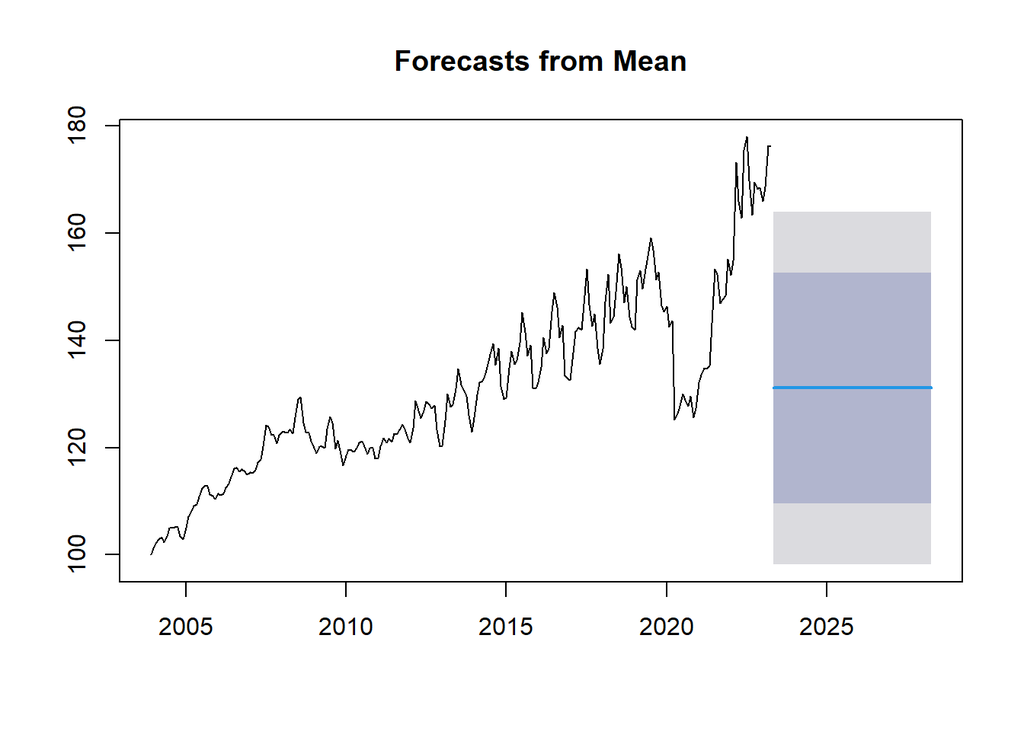

```r
# prognozowanie naiwne oparte na sredniej
szereg1.meanf <- meanf(szereg1, h = 60)
plot(szereg1.meanf)
```

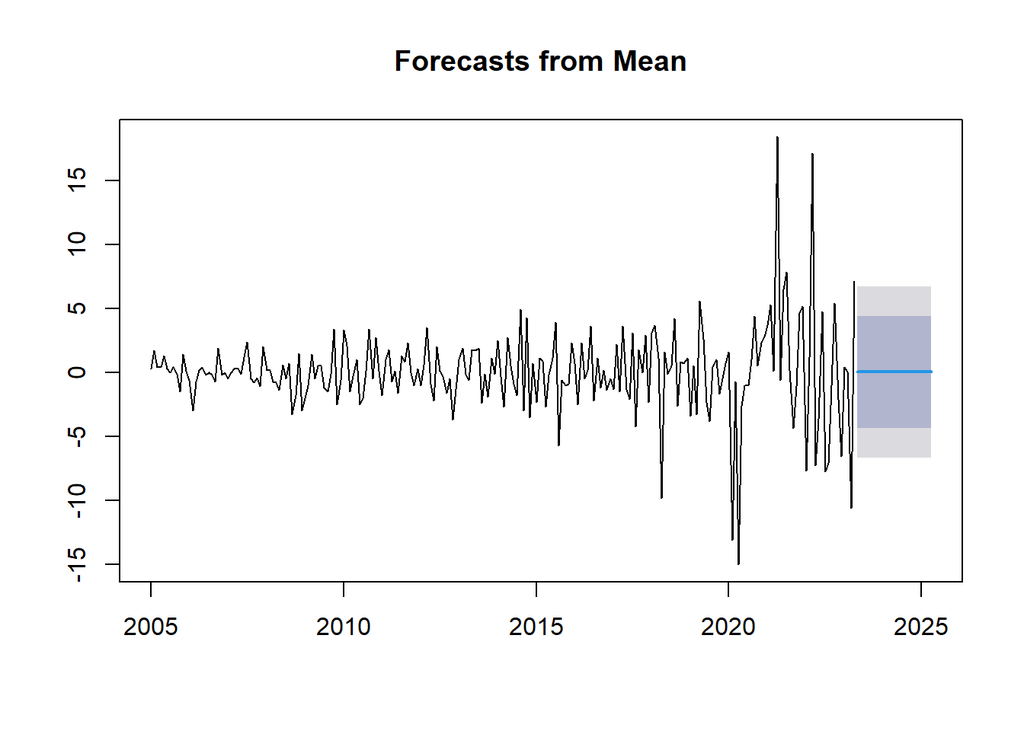

```r
#usuniecie trendu i sezonowosci

szereg1.meanf2 <- meanf(szereg1diff12, h=24)
plot(szereg1.meanf2)
```

### prognozowanie naiwne

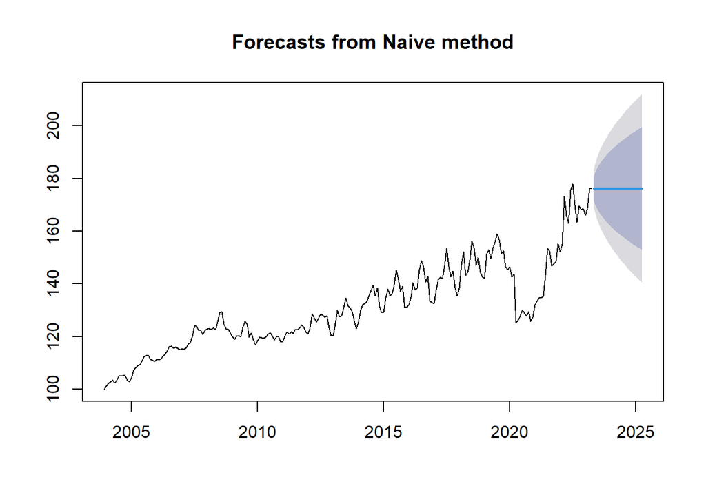

```r
#prognozowanie naiwne
pnaiwnes1 <- naive(szereg1, h=24)
plot(pnaiwnes1)
```

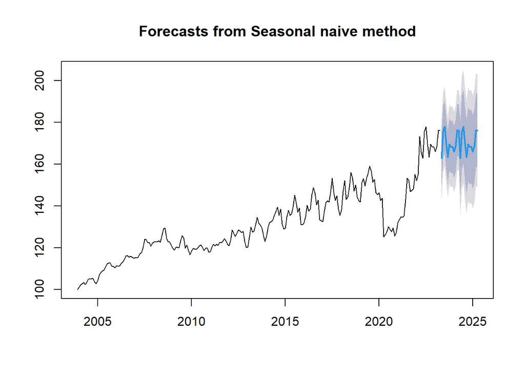

```r
psnaiwnes1 <- snaive(szereg1, h=24)
plot(psnaiwnes1)
```